# Movie Awards

Catherine Williams et al.

June 5, 2019

# 1 Problem

IMDB has immense amounts of data regarding movies. This data can be used to predict movie awards (Oscar, Golden Globes, Bafta, etc). This will help to understand which combination of feature values contribute to bringing a film to success and consequently winning awards. This will almost certainly lead to an increase of profit for those involved in making the film as well.

# 2 Dataset

36 predictor variables

- 28 discrete
- 8 continuous

Label is continuous

## 2.1 Ground Truths

Number of Wins

nrOfWins - Number of prizes won by the movie. It is an indicative number that certifies how many are the prizes won even after the first year of release (Oscar, Golden Globe, Bafta, …)

## 2.2 Source

https://www.kaggle.com/gabrielegalimberti/movies-example-for-machine-learning-activities/

# 3 Setup

## 3.1 Load libraries

```r
ipak <- function(pkg){
  new.pkg <- pkg[!(pkg %in% installed.packages()[, "Package"])]
if (length(new.pkg))
    install.packages(new.pkg, dependencies = TRUE)
sapply(pkg, require, character.only = TRUE)
}

packages <- c("tidyverse","caret","performance","Amelia","rpart","rpart.plot","randomForest","fastDummies")
ipak(packages)

theme_set(theme_classic()) #applies classic theme to all charts
```

## 3.2 Import Data

```r
movies <- read.csv2("MACHINE_LEARNING_FINAL.csv")
```

## 3.3 Change Data Types

```r
#change variables to appropriate data types. this will be important for charting later
movies <- movies %>% mutate_at(vars(Action:Western),as.logical)
movies <- movies %>% mutate_at(vars(ratingInteger,nrOfGenre),as.factor)
```

# 4 Exploratory Data Analysis

## 4.1 View Data

## 4.2 Missing Values

There are no missing values

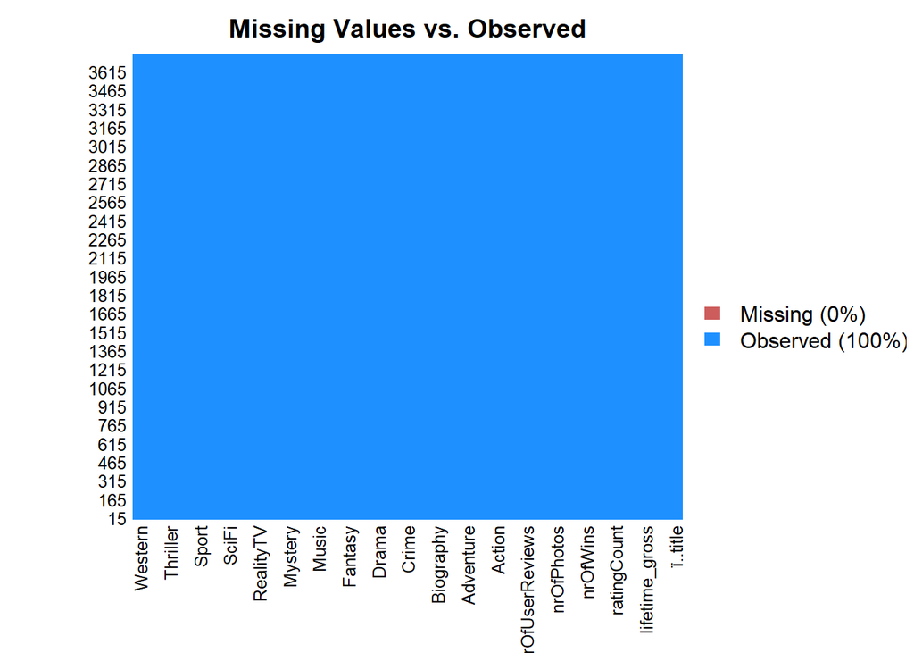

```r
#Visualize missing values
missmap(movies, main = "Missing Values vs. Observed")
```

## 4.3 Correlations

There are some variables with high correlations (>|0.5|) that will need to have feature engineering. There are also some moderate correlations (|0.3| to |0.5|) that should be monitored but do not necessarily need to be excluded initially.

```
##                  Var1             Var2       Freq
## 329       ratingCount  nrOfUserReviews  0.7760283
## 147    lifetime_gross      ratingCount  0.6449900
## 293       ratingCount nrOfNewsArticles  0.5837222
## 332        nrOfPhotos  nrOfUserReviews  0.5616223
## 327    lifetime_gross  nrOfUserReviews  0.5584999
## 255    lifetime_gross       nrOfPhotos  0.5553002
## 221       ratingCount  nrOfNominations  0.5403624
## 257       ratingCount       nrOfPhotos  0.5385229
## 291    lifetime_gross nrOfNewsArticles  0.5237748
## 331   nrOfNominations  nrOfUserReviews  0.5152443
## 333  nrOfNewsArticles  nrOfUserReviews  0.4669062
## 295   nrOfNominations nrOfNewsArticles  0.4521882
## 296        nrOfPhotos nrOfNewsArticles  0.4286632
## 148     ratingInteger      ratingCount  0.4147697
## 219    lifetime_gross  nrOfNominations  0.4146209
## 220     ratingInteger  nrOfNominations  0.4088316
## 259   nrOfNominations       nrOfPhotos  0.4008487
## 184     ratingInteger         duration  0.3238626
## 518         Adventure        Animation  0.3206551
## 690          duration            Drama  0.3167713
## 471    lifetime_gross        Adventure  0.3089379
## 1205           Comedy         Thriller -0.3061384
## 222          duration  nrOfNominations  0.3033252
```

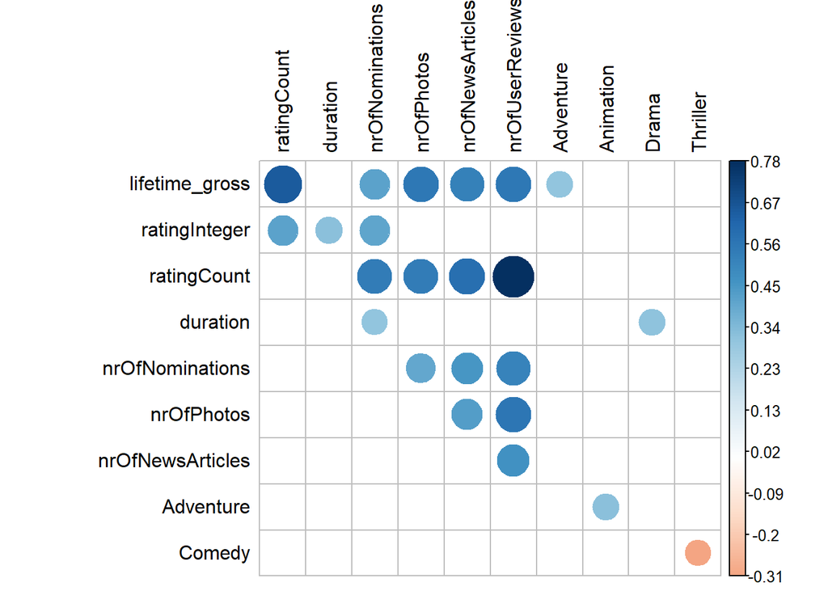

```r
#view correlations, drop the insignificant relationships, sort by highest to lowest, and visualize results graphically
corr_simple <- function(data=movies,drop="nrOfWins"){
  df_cor <- data %>% mutate_if(is.factor, as.numeric) %>% select(-drop)

  corr <- cor(df_cor)
  corr[lower.tri(corr,diag=TRUE)] <- NA  #Prepare to drop duplicates and correlations of 1
  corr[corr == 1] <- NA #drop perfect correlations
  corr <- as.data.frame(as.table(corr)) #Turn into a 3-column table
  corr <- na.omit(corr) #remove the NA values from above
  corr <- subset(corr, abs(Freq) > 0.3) #select significant values
  corr <- corr[order(-abs(corr$Freq)),] #Sort by highest correlation
  print(corr)

  #turn corr back into matrix in order to plot with corrplot
  mtx_corr <- reshape2::acast(corr, Var1~Var2, value.var="Freq")

  #plot correlations visually
  corrplot::corrplot(mtx_corr, is.corr=FALSE, tl.col="black", na.label=" ")
}

corr_simple()
```

## 4.4 Variable Trends

Conclusions made from these charts:

- Recent years have more data points. This could be due to increased user adoption on IMDB.
- It appears there are positive relationships between the number of awards and lifetime gross, rating count, number of pictures, news articles, and user reviews. However, most of the data is clustered at lower values so these may not be very strong predictors.
- The higher the rating, the higher the number of awards won with a few outliers. There is a large increase in number of awards with ratings of 8 and 9.
- Movie duration doesn't necessarily relate to number of awards.
- Unsurprisingly, the number of nominations has a very strong positive relationship with the number of awards.
- Movie genres do not appear to play a big role in number of awards except for Biography and War films.

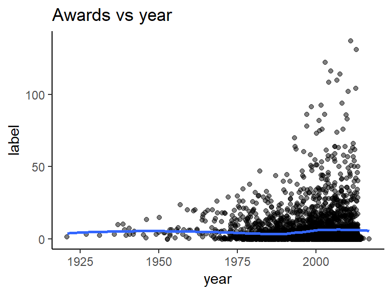

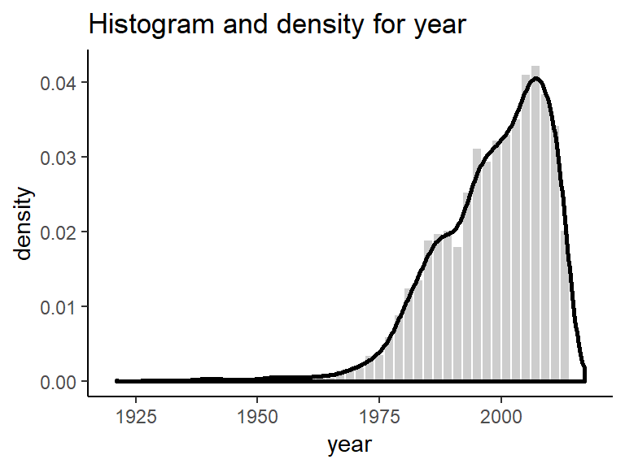

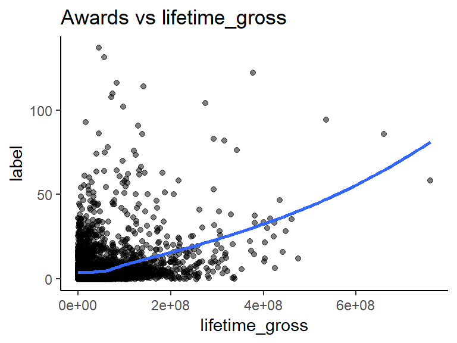

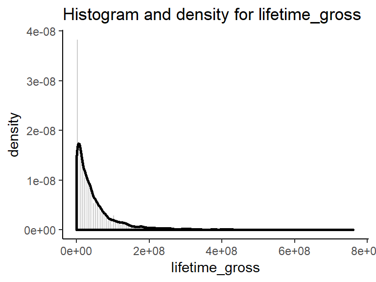

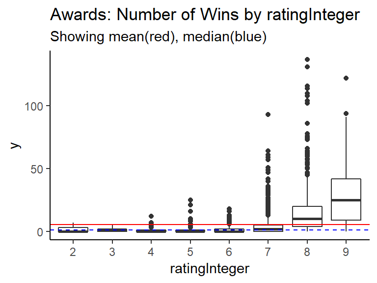

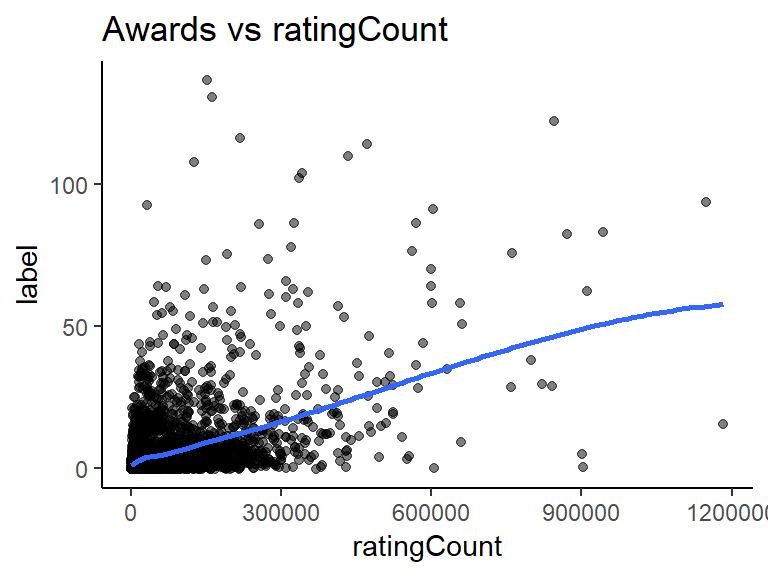

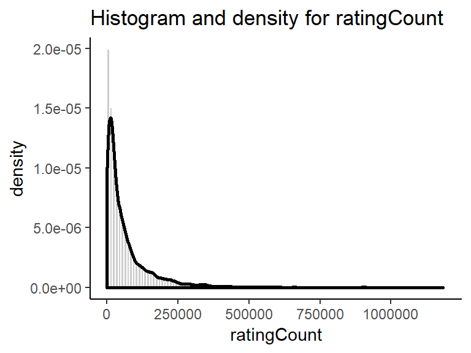

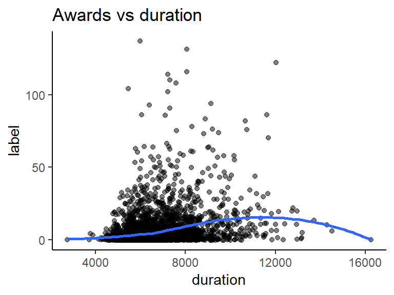

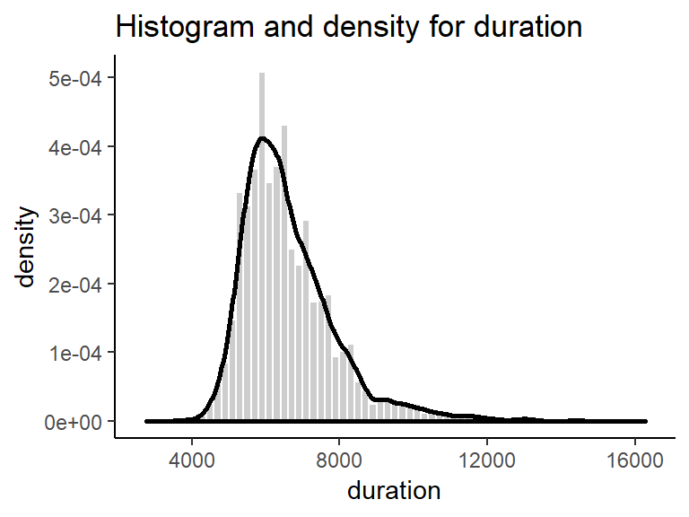

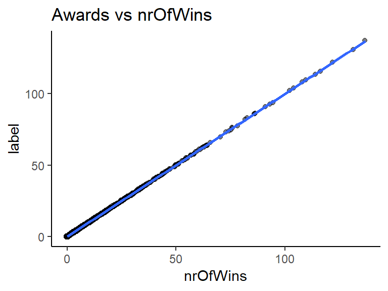

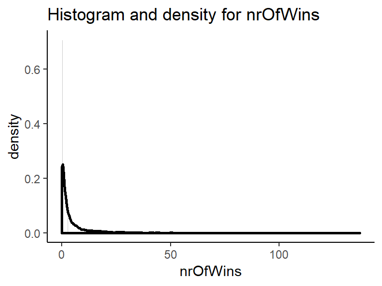

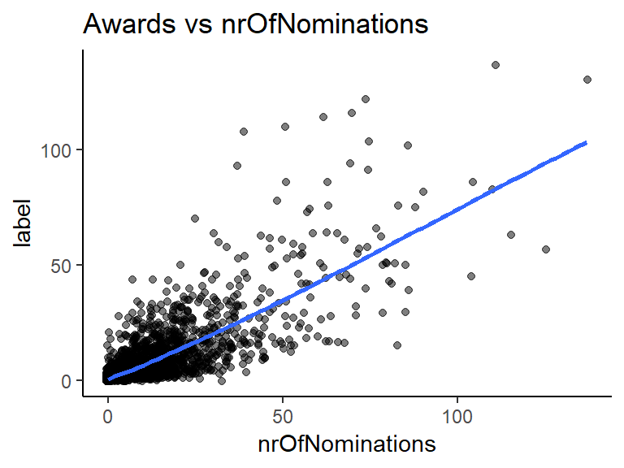

[33 more figures not shown]

```r
gg_plot <- function(x_col, y_col=movies$nrOfWins, data=movies){
  if(is.numeric(data[[x_col]])){
      p1 <- data %>% ggplot(mapping=aes_string(x_col, y_col))+
        geom_jitter(alpha=0.5)+
        geom_smooth(method="loess", se=FALSE)+
        labs(title=str_c("Awards vs ", x_col), y="label")
      p1 %>% print()
      h <- hist(data[[x_col]], breaks = "FD", plot = FALSE) #histogram with Freedman-Diaconis rule for binwidth
      p2 <- ggplot(data, aes_string(x_col))+
        geom_histogram(aes(y = ..density..), breaks = h$breaks, alpha = 0.3, col = "white")+
        geom_density(size = 1) +
        labs(title=str_c("Histogram and density for ", x_col))
      p2 %>% print()
    }
  else{
    p3 <- ggplot(data, aes_string(x_col, y_col))+
      geom_boxplot()+
      geom_hline(yintercept=mean(y_col), color="red")+
      geom_hline(yintercept=median(y_col), color="blue", linetype="dashed")+
      labs(title=str_c("Awards: Number of Wins by ", x_col), subtitle="Showing mean(red), median(blue)")
    p3 %>% print()
    }
}

cols <- movies %>% select(-1) %>% names()
cols %>% walk(gg_plot)
```

# 5 Data Wrangling

## 5.1 Data Cleaning

- Excluded columns that don't have any useful data
- Removed outliers for year, ratingCount, and nrOfPhotos (these all improved model performance)

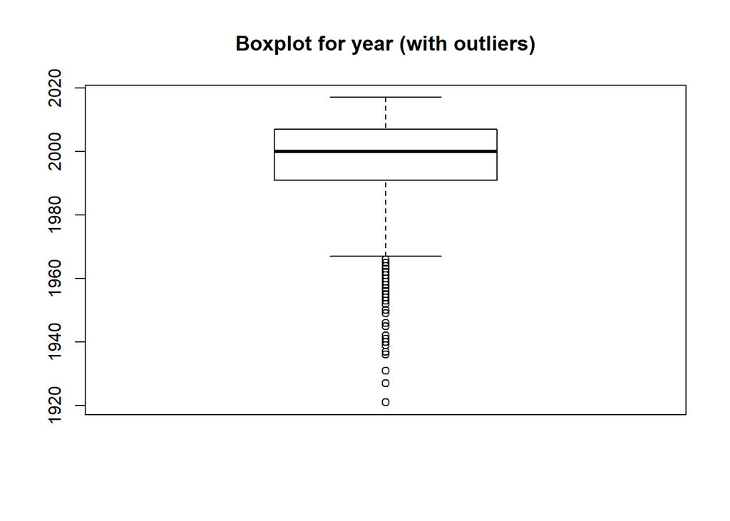

```r
#remove movie title and columns that do not have more than 1 unique value (Adult, RealityTV, TalkShow)
movies <- movies[, sapply(movies, function(col) length(unique(col))) > 1] %>% select(-1)

#Exclude outliers for year
outliers <- boxplot(movies$year, main="Boxplot for year (with outliers)")$out
```

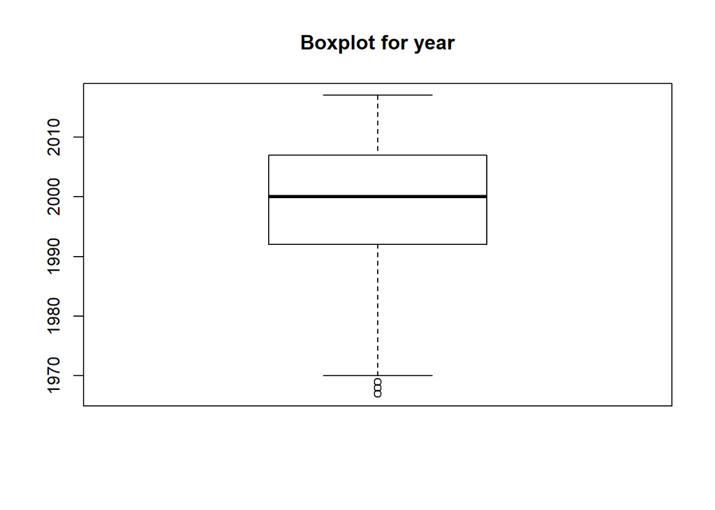

```r
movies <- movies[-which(movies$year %in% outliers),]
#view new boxplot after outliers have been removed
boxplot(movies$year, main="Boxplot for year")
```

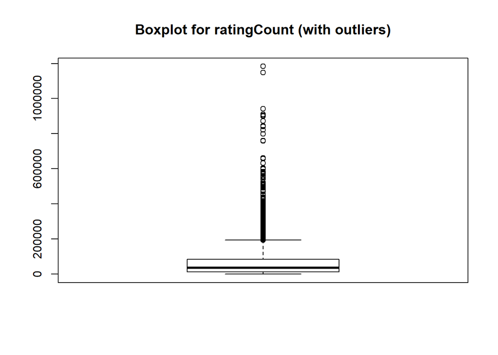

```r
#Exclude outliers for ratingCount
outliers <- boxplot(movies$ratingCount, main="Boxplot for ratingCount (with outliers)")$out
```

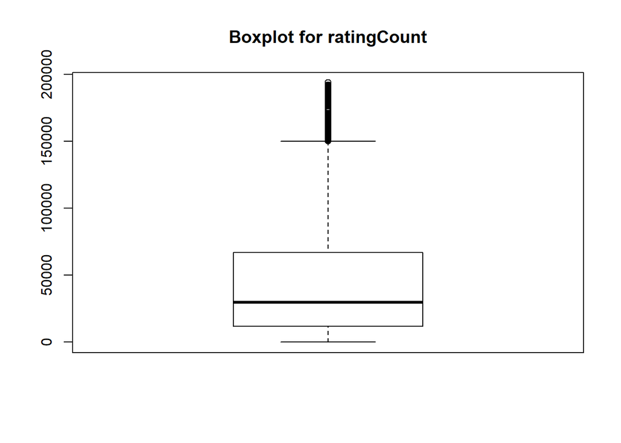

```r
movies <- movies[-which(movies$ratingCount %in% outliers),]
#view new boxplot after outliers have been removed
boxplot(movies$ratingCount, main="Boxplot for ratingCount")
```

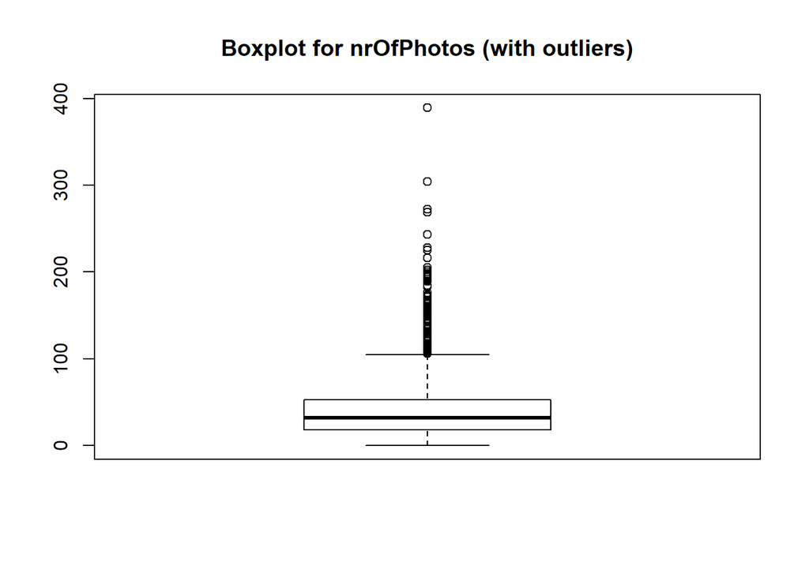

```r
#Exclude outliers for nrOfPhotos
outliers <- boxplot(movies$nrOfPhotos, main="Boxplot for nrOfPhotos (with outliers)")$out
```

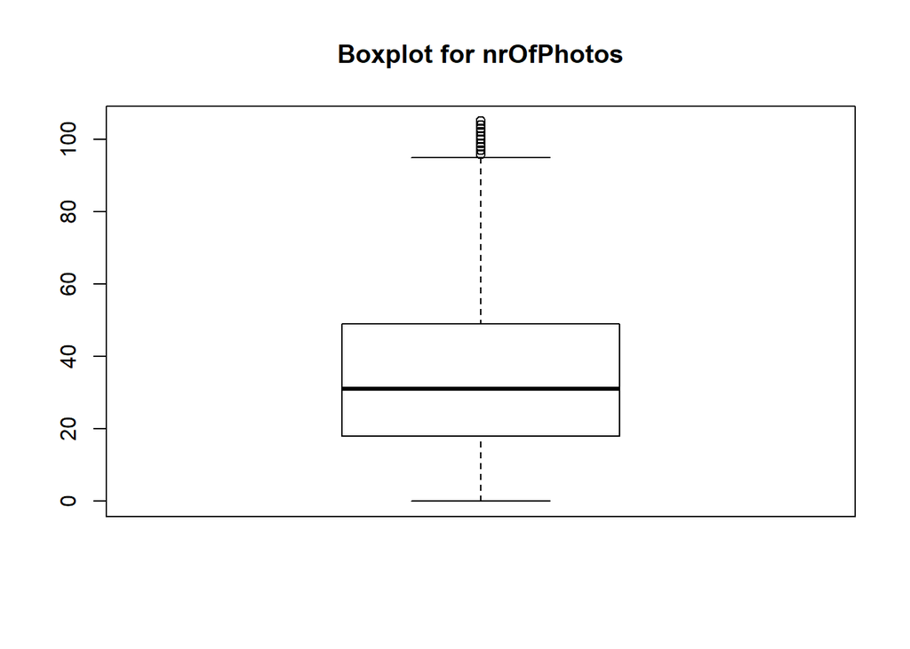

```r
movies <- movies[-which(movies$nrOfPhotos %in% outliers),]
#view new boxplot after outliers have been removed
boxplot(movies$nrOfPhotos, main="Boxplot for nrOfPhotos")
```

## 5.2 Feature Engineering

Popularity was created to remove some correlated variables.

Logarithmic and square root transformations were performed to improve the distributions of numeric variables. Overall, logarithmic transformations performed better but if there were zeros in the data, square root transformations were used instead to avoid having infinite values.

```r
movies <- movies %>% mutate(Popularity = ratingCount+nrOfUserReviews+nrOfNewsArticles+nrOfPhotos) %>%
                    select(-ratingCount,-nrOfUserReviews,-nrOfNewsArticles,-nrOfPhotos)

movies <- movies %>%
   mutate(year.log=log(year),
          duration.log=log(duration),
          Popularity.log=log(Popularity),
          lifetime_gross.log=log(lifetime_gross),
          nrOfWins.sqr = sqrt(nrOfWins),
          nrOfNominations.sqr = sqrt(nrOfNominations)) %>%
  select(-year,-duration,-Popularity,-nrOfNominations,-lifetime_gross)

movies %>% glimpse()
```

```
## Observations: 3,234
## Variables: 31
## $ ratingInteger       <fct> 8, 8, 8, 8, 8, 8, 8, 8, 8, 8, 8, 8, 8, 8, ...
## $ nrOfWins            <int> 20, 18, 10, 20, 13, 22, 26, 21, 10, 26, 0,...
## $ nrOfGenre           <fct> 3, 3, 3, 3, 2, 1, 2, 2, 2, 3, 3, 2, 2, 3, ...
## $ Action              <lgl> FALSE, FALSE, FALSE, FALSE, FALSE, FALSE, ...
## $ Adventure           <lgl> FALSE, TRUE, FALSE, FALSE, FALSE, FALSE, F...
## $ Animation           <lgl> FALSE, FALSE, FALSE, FALSE, FALSE, FALSE, ...
## $ Biography           <lgl> FALSE, TRUE, FALSE, FALSE, FALSE, FALSE, F...
## $ Comedy              <lgl> TRUE, FALSE, TRUE, FALSE, FALSE, FALSE, TR...
## $ Crime               <lgl> FALSE, TRUE, TRUE, FALSE, TRUE, FALSE, FAL...
## $ Documentary         <lgl> FALSE, FALSE, FALSE, FALSE, FALSE, FALSE, ...
## $ Drama               <lgl> TRUE, FALSE, TRUE, TRUE, TRUE, TRUE, FALSE...
## $ Family              <lgl> FALSE, FALSE, FALSE, FALSE, FALSE, FALSE, ...
## $ Fantasy             <lgl> FALSE, FALSE, FALSE, FALSE, FALSE, FALSE, ...
```

[output cut: 18 more lines]

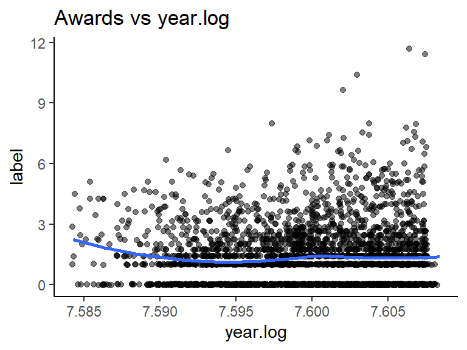

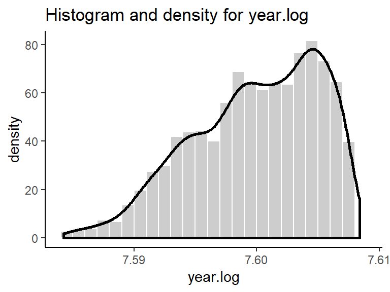

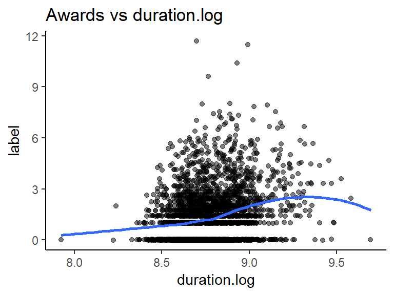

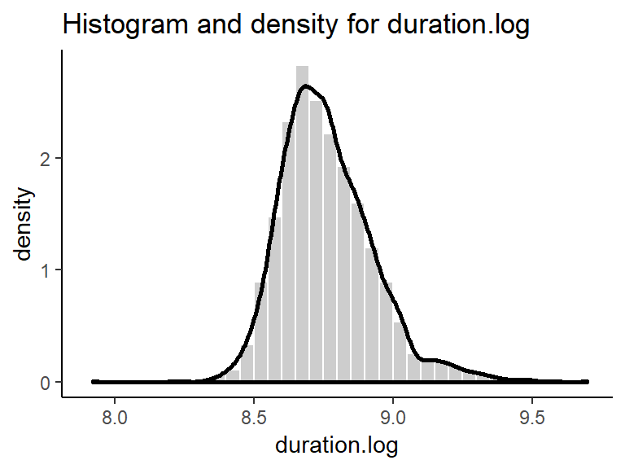

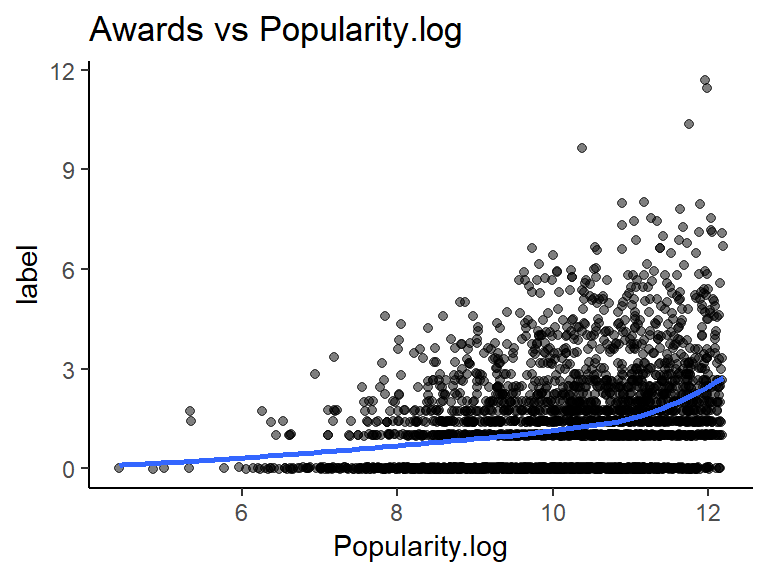

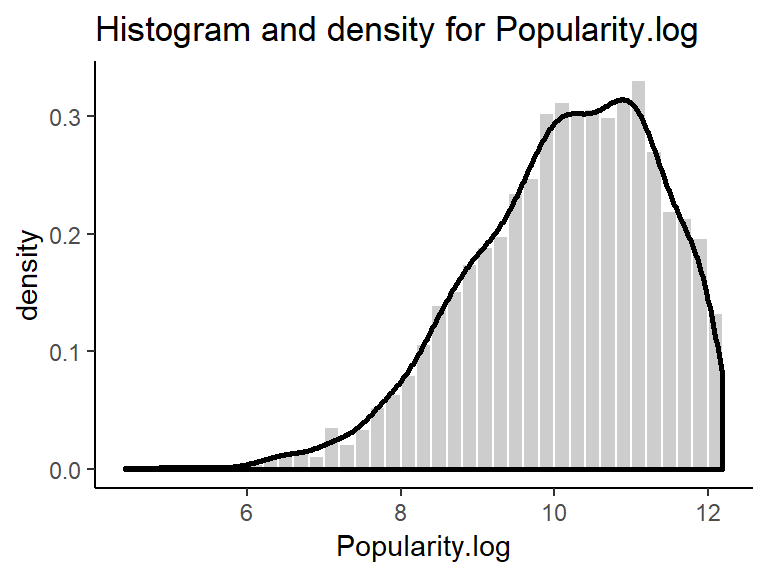

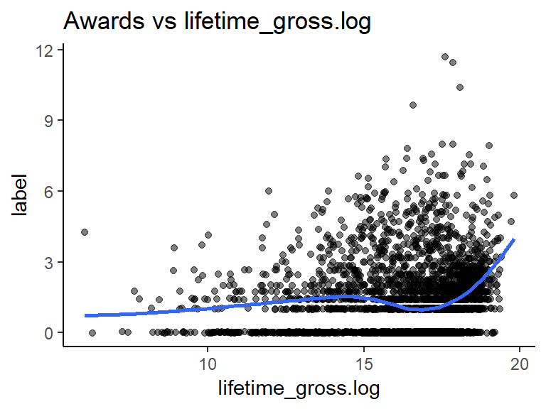

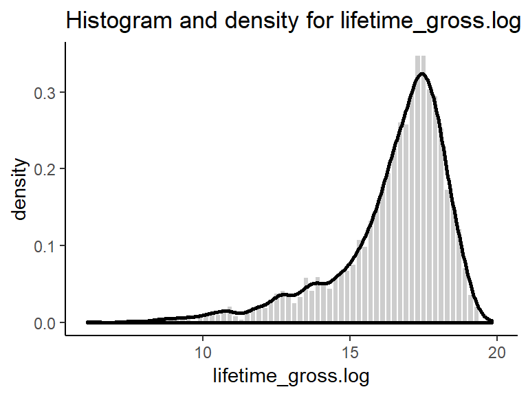

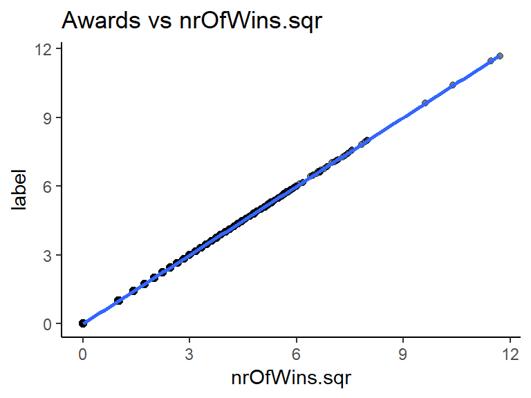

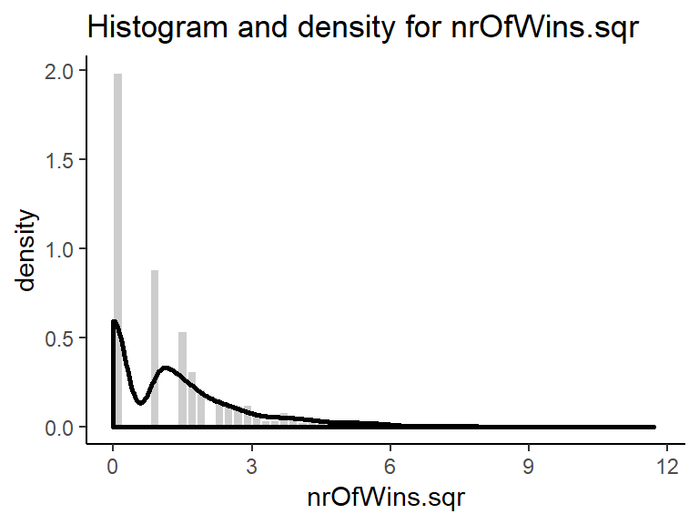

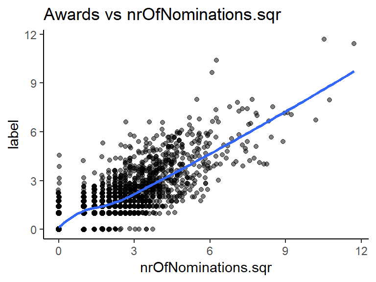

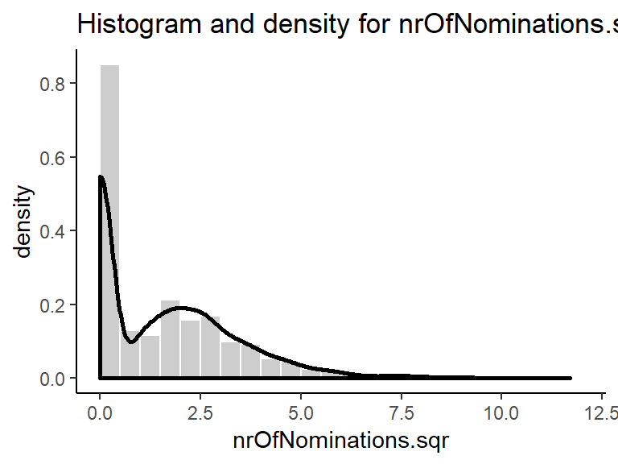

```r
cols <- movies %>% select(26:31) %>% names()
cols %>% walk(gg_plot, y_col=movies$nrOfWins.sqr)
```